```r
library(readr)
library(tidyverse)
library(tidymodels)
library(kknn)
```

# **GSE 524 Lab 7**

## Instructions

You will submit an HTML document to Canvas as your final version.

Your document should show your code chunks/cells as well as any output. Make sure that only relevant output is printed. Do not, for example, print the entire dataset in your final knitted file.

Your document should also be clearly organized, so that it is easy for a reader to find your answers to each question.

The Data In this lab, we will use medical data to predict the likelihood of a person experiencing an exercise-induced heart attack.

Our dataset consists of clinical data from patients who entered the hospital complaining of chest pain (“angina”) during exercise. The information collected includes:

-age : Age of the patient

-sex : Sex of the patient

-cp : Chest Pain type

- Value 1: typical angina
- Value 2: atypical angina
- Value 3: non-anginal pain
- Value 4: asymptomatic trtbps : resting blood pressure (in mm Hg)

-chol : cholesterol in mg/dl fetched via BMI sensor

-restecg : resting electrocardiographic results

- Value 0: normal
- Value 1: having ST-T wave abnormality (T wave inversions and/or ST elevation or depression of > 0.05 mV)
- Value 2: showing probable or definite left ventricular hypertrophy by Estes’ criteria thalach : maximum heart rate achieved during exercise

-output : the doctor’s diagnosis of whether the patient is at risk for a heart attack

- 0 = not at risk of heart attack
- 1 = at risk of heart attack

```r
ha <- read_csv("https://www.dropbox.com/s/aohbr6yb9ifmc8w/heart_attack.csv?dl=1")
head(ha)
```

```
## # A tibble: 6 × 8
##     age   sex    cp trtbps  chol restecg thalach output
##   <dbl> <dbl> <dbl>  <dbl> <dbl>   <dbl>   <dbl>  <dbl>
## 1    63     1     3    145   233       0     150      1
## 2    37     1     2    130   250       1     187      1
## 3    56     1     1    120   236       1     178      1
## 4    57     0     0    120   354       1     163      1
## 5    57     1     0    140   192       1     148      1
## 6    56     0     1    140   294       0     153      1
```

```r
summary(ha)
```

```
##       age             sex              cp             trtbps
##  Min.   :29.00   Min.   :0.000   Min.   :0.0000   Min.   : 94.0
##  1st Qu.:47.00   1st Qu.:0.000   1st Qu.:0.0000   1st Qu.:120.0
##  Median :56.00   Median :1.000   Median :1.0000   Median :130.0
##  Mean   :54.35   Mean   :0.674   Mean   :0.9744   Mean   :132.1
##  3rd Qu.:61.00   3rd Qu.:1.000   3rd Qu.:2.0000   3rd Qu.:140.0
##  Max.   :77.00   Max.   :1.000   Max.   :3.0000   Max.   :200.0
##       chol          restecg          thalach          output
##  Min.   :126.0   Min.   :0.0000   Min.   : 71.0   Min.   :0.0000
##  1st Qu.:211.0   1st Qu.:0.0000   1st Qu.:133.0   1st Qu.:0.0000
##  Median :240.0   Median :1.0000   Median :152.0   Median :1.0000
##  Mean   :246.9   Mean   :0.5385   Mean   :149.4   Mean   :0.5348
##  3rd Qu.:275.0   3rd Qu.:1.0000   3rd Qu.:166.0   3rd Qu.:1.0000
##  Max.   :564.0   Max.   :2.0000   Max.   :202.0   Max.   :1.0000
```

```r
ha <- ha %>%
  mutate(sex = as.factor(sex), cp = as.factor(cp), restecg = as.factor(restecg), output = as.factor(output))
```

## Part One: Fitting Models

This section asks you to create a final best model for each of the model types studied this week. For each, you should:

- Find the best model based on roc.auc for predicting the target variable.
- Output a confusion matrix; that is, the counts of how many observations fell into each predicted class for each true class. (Hint: Code is provided from lecture; alternatively, conf_mat is a nice shortcut function for this task.)
- Report the (cross-validated!) roc.auc metric.
- Fit the final model.
- (Where applicable) Interpret the coefficients and/or estimates produced by the model fit.

You should certainly try multiple model recipes to find the best model. You do not need to include the output for every attempted model, but you should describe all of the models explored. You should include any hyper parameter tuning steps in your writeup as well.

```r
ha_cv <- vfold_cv(ha, v = 5)
set.seed(10)

ha_recipe1 <- recipe(output ~ sex + cp + trtbps + thalach, data = ha) %>%
  step_normalize(all_numeric()) %>%
  step_dummy(all_nominal(), -output)

ha_recipe2 <- recipe(output ~ sex + cp + trtbps + age, data = ha) %>%
  step_normalize(all_numeric()) %>%
  step_dummy(all_nominal(), -output)

ha_recipe3 <- recipe(output ~ cp + age + thalach + restecg,, data = ha) %>%
  step_normalize(all_numeric()) %>%
  step_dummy(all_nominal(), -output)
```

**Q1: KNN**

```r
knn_spec <- nearest_neighbor(neighbors = tune()) %>%
  set_engine("kknn") %>%
  set_mode("classification")

k_grid <- grid_regular(neighbors(c(2, 40)), levels = 10)
set.seed(10)

knn_wflow <- workflow() %>%
  add_model(knn_spec) %>%
  add_recipe(ha_recipe1)

knn_wflow %>%
  tune_grid(
    grid = k_grid,
    resamples = ha_cv
  ) %>%
  collect_metrics() %>%
  filter(.metric == "roc_auc") %>%
  arrange(desc(mean))
```

```
## # A tibble: 10 × 7
##    neighbors .metric .estimator  mean     n std_err .config
##        <int> <chr>   <chr>      <dbl> <int>   <dbl> <chr>
##  1        31 roc_auc binary     0.856     5  0.0270 Preprocessor1_Model08
##  2        27 roc_auc binary     0.856     5  0.0282 Preprocessor1_Model07
##  3        23 roc_auc binary     0.854     5  0.0291 Preprocessor1_Model06
##  4        35 roc_auc binary     0.854     5  0.0267 Preprocessor1_Model09
##  5        40 roc_auc binary     0.854     5  0.0273 Preprocessor1_Model10
##  6        18 roc_auc binary     0.847     5  0.0282 Preprocessor1_Model05
##  7        14 roc_auc binary     0.843     5  0.0269 Preprocessor1_Model04
##  8        10 roc_auc binary     0.829     5  0.0290 Preprocessor1_Model03
##  9         6 roc_auc binary     0.808     5  0.0301 Preprocessor1_Model02
## 10         2 roc_auc binary     0.761     5  0.0204 Preprocessor1_Model01
```

- At k=31 the best roc_auc was found.

```r
knn_spec_final <- nearest_neighbor(neighbors = 31 ) %>%
  set_engine("kknn") %>%
  set_mode("classification")

knn_wflow <- workflow() %>%
  add_model(knn_spec_final) %>%
  add_recipe(ha_recipe1)

knn_final <- knn_wflow %>% fit(ha)

knn_preds <- predict(knn_final, ha)

ha %>%
  mutate(
   preds = knn_preds$.pred_class
  ) %>%
  count(preds, output)
```

```
## # A tibble: 4 × 3
##   preds output     n
##   <fct> <fct>  <int>
## 1 0     0         97
## 2 0     1         22
## 3 1     0         30
## 4 1     1        124
```

- Recipe 1 had the highest auc and roc_auc when compared to the other recipes.

**Q2: Logistic Regression**

```r
lr_spec <- logistic_reg() %>%
  set_engine("glm") %>%
  set_mode("classification")

lr_wflow <- workflow() %>%
  add_model(lr_spec) %>%
  add_recipe(ha_recipe1)

lr_wflow %>%
  fit_resamples(ha_cv) %>%
  collect_metrics()
```

```
## # A tibble: 2 × 6
##   .metric  .estimator  mean     n std_err .config
##   <chr>    <chr>      <dbl> <int>   <dbl> <chr>
## 1 accuracy binary     0.762     5  0.0262 Preprocessor1_Model1
## 2 roc_auc  binary     0.866     5  0.0230 Preprocessor1_Model1
```

```r
lr_final <- lr_wflow %>% fit(ha)

lr_preds <- predict(lr_final, ha)

ha %>%
  mutate(
   preds = lr_preds$.pred_class
  ) %>%
  count(preds, output)
```

```
## # A tibble: 4 × 3
##   preds output     n
##   <fct> <fct>  <int>
## 1 0     0         92
## 2 0     1         24
## 3 1     0         35
## 4 1     1        122
```

```r
lr_fit <- lr_final %>% pull_workflow_fit()
lr_fit$fit %>% summary()
```

```
##
## Call:
## stats::glm(formula = ..y ~ ., family = stats::binomial, data = data)
##
## Deviance Residuals:
##     Min       1Q   Median       3Q      Max
## -2.6980  -0.6667   0.2246   0.7023   2.5616
##
## Coefficients:
##             Estimate Std. Error z value Pr(>|z|)
## (Intercept)   0.3941     0.3213   1.227  0.21999
## trtbps       -0.4692     0.1631  -2.877  0.00402 **
## thalach       0.8591     0.1908   4.503 6.69e-06 ***
## sex_X1       -1.9529     0.3812  -5.123 3.00e-07 ***
## cp_X1         2.2555     0.5061   4.456 8.34e-06 ***
## cp_X2         2.1188     0.3816   5.552 2.82e-08 ***
## cp_X3         1.9342     0.5966   3.242  0.00119 **
## ---
## Signif. codes:  0 '***' 0.001 '**' 0.01 '*' 0.05 '.' 0.1 ' ' 1
##
## (Dispersion parameter for binomial family taken to be 1)
##
##     Null deviance: 377.13  on 272  degrees of freedom
## Residual deviance: 244.94  on 266  degrees of freedom
## AIC: 258.94
##
## Number of Fisher Scoring iterations: 5
```

-Chest Pain category 1 have 2.26 higher log-odds of having a risk of heart attack on average Chest Pain category 2 have 2.12 higher log-odds of having a risk of heart attack on average Chest Pain category 3 have 1.93 higher log-odds of having a risk of heart attack on average

**Q3: Interpretation**

Which predictors were most important to predicting heart attack risk?

- CP is the most important in prediciting heart attack risk followed by sex

**Q4: ROC**

Curve Plot the ROC Curve for your two models above.

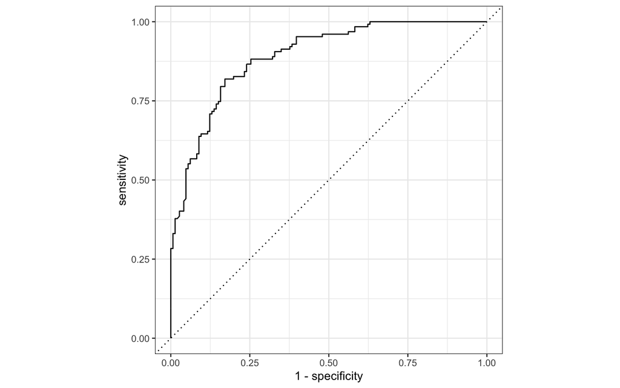

```r
ha %>%
  mutate(
    preds = predict(knn_final, ha, type = "prob")$.pred_0
  ) %>%
  roc_curve(
    truth = output,
    preds
  ) %>%
  autoplot()
```

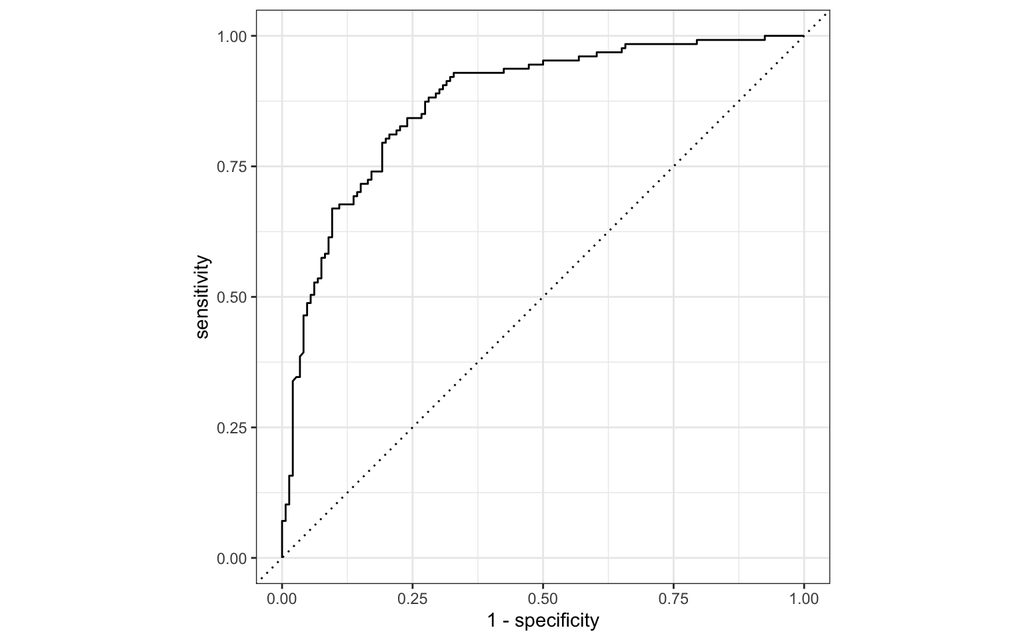

```r
ha %>%
  mutate(
    preds = predict(lr_final, ha, type = "prob")$.pred_0
  ) %>%
  roc_curve(
    truth = output,
    preds
  ) %>%
  autoplot()
```

## Part Two: Metrics

Consider the following metrics:

- True Positive Rate or Recall or Sensitivity = Of the observations that are truly Class A, how many were predicted to be Class A?
- Precision or Positive Predictive Value = Of all the observations classified as Class A, how many of them were truly from Class A?
- True Negative Rate or Specificity or Negative Predictive Value = Of all the observations classified as NOT Class A, how many were truly NOT Class A?

Compute each of these metrics (cross-validated) for your four models in Part One.

```r
knn_wflow %>%
  fit_resamples(ha_cv,
                metrics = metric_set(precision, recall, specificity, accuracy)) %>%
  collect_metrics()
```

```
## # A tibble: 4 × 6
##   .metric     .estimator  mean     n std_err .config
##   <chr>       <chr>      <dbl> <int>   <dbl> <chr>
## 1 accuracy    binary     0.766     5  0.0140 Preprocessor1_Model1
## 2 precision   binary     0.753     5  0.0675 Preprocessor1_Model1
## 3 recall      binary     0.780     5  0.0427 Preprocessor1_Model1
## 4 specificity binary     0.757     5  0.0638 Preprocessor1_Model1
```

```r
lr_wflow %>%
  fit_resamples(ha_cv,
                metrics = metric_set(precision, recall, specificity, accuracy)) %>%
  collect_metrics()
```

```
## # A tibble: 4 × 6
##   .metric     .estimator  mean     n std_err .config
##   <chr>       <chr>      <dbl> <int>   <dbl> <chr>
## 1 accuracy    binary     0.762     5  0.0262 Preprocessor1_Model1
## 2 precision   binary     0.768     5  0.0554 Preprocessor1_Model1
## 3 recall      binary     0.708     5  0.0577 Preprocessor1_Model1
## 4 specificity binary     0.811     5  0.0400 Preprocessor1_Model1
```

## Part Three: Discussion

Suppose you have been hired by a hospital to create classification models for heart attack risk.

The following questions give a possible scenario for why the hospital is interested in these models. For each one, discuss:

- Which metric(s) you would use for model selection and why.
- Which of your final models (Part One Q1-4) you would recommend to the hospital, and why.
- What score you should expect for your chosen metric(s) using your chosen model to predict future observations.

**Q1**

The hospital faces severe lawsuits if they deem a patient to be low risk, and that patient later experiences a heart attack.

- Metric: Recall would be the metric in this case, since it tells us the number of successful predictions
- Model: I would use the Knn model since it had the highest recall.
- Score: We expect a high recall score using the Knn model.

**Q2**

**Q3**

The hospital is studying root causes of heart attacks, and would like to understand which biological measures are associated with heart attack risk.

- Metric: Roc_Auc would be the metric in this case, since it tells us how the model performed overall.
- Model: I would use the log model since it has better interpretability.
- Score: We expect a high Roc_Auc score using the logistic reg model.

**Q4**

The hospital is training a new batch of doctors, and they would like to compare the diagnoses of these doctors to the predictions given by the algorithm to measure the ability of new doctors to diagnose patients.

- Metric: Accuracy would be the metric in this case, since it tells us how often the model was correct.
- Model: I would use the Knn model since it had the highest accuracy
- Score: We expect a high accuracy score using the Knn model.

## Part Four: Validation

Before sharing the dataset with you, I set aside a random 10% of the observations to serve as a final validation set.

```r
ha_validation <- read_csv("https://www.dropbox.com/s/jkwqdiyx6o6oad0/heart_attack_validation.csv?dl=1")
ha_validation <- ha_validation %>%
  mutate(
    sex = factor(sex),
    cp = factor(cp),
    restecg = factor(restecg),
    output = factor(output)
  ) %>%
  drop_na()
```

Use each of your final models in Part One Q1-2, predict the target variable in the validation dataset.

```r
ha_validation <- ha_validation %>%
  mutate(
    knn_pred = predict(knn_final, ha_validation)$.pred_class,
    knn_pred_prob = predict(knn_final, ha_validation, type = "prob")$.pred_0,
    lr_pred = predict(lr_final, ha_validation)$.pred_class,
    lr_pred_prob = predict(lr_final, ha_validation, type = "prob")$.pred_0
  )
```

For each, output a confusion matrix, and report the roc.auc, the precision, and the recall.

```r
my_metrics <- metric_set(roc_auc, precision, recall)

ha_validation %>%
  my_metrics(truth = output, knn_pred_prob, estimate = knn_pred)
```

```
## # A tibble: 3 × 3
##   .metric   .estimator .estimate
##   <chr>     <chr>          <dbl>
## 1 precision binary         0.692
## 2 recall    binary         0.818
## 3 roc_auc   binary         0.842
```

```r
ha_validation %>%
  my_metrics(truth = output, lr_pred_prob, estimate = lr_pred)
```

```
## # A tibble: 3 × 3
##   .metric   .estimator .estimate
##   <chr>     <chr>          <dbl>
## 1 precision binary         0.643
## 2 recall    binary         0.818
## 3 roc_auc   binary         0.880
```

Compare these values to the cross-validated estimates you reported in Part One and Part Two. Did our measure of model success turn out to be approximately correct for the validation data?